# S371: Lab 6

Lab Instructor: Katya Baldina (baldina@iu.edu)

2023-09-27

# Announcement

HW 3 IS DUE SATURDAY (SEP.30)!

# Today

- Bivariate graphs
- Scatter plot
- Sampling
- Central Limit Theorem
- HW3 Guide

# Bivariate plots

| Variable | Quantitative | Categorical |
| --- | --- | --- |
| Quantitative | Scatter plot | Box plot, bar chart |
| Categorical | Box plot, bar chart | Table or bar chart |

Today we will cover bivariate graph for quantitative- quantitative variables only

# Scatter plot

To visualize the relationships between two quantitative variables type:

```r
plot(x, y) #x and y are names for your variables
```

The plot() command in R is a generic plot command that can actually produce many kinds of plots (e.g., distribution function)

# Scatter plot

There are many options in `plot()`:

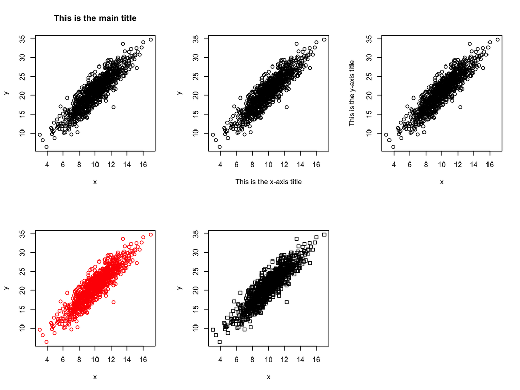

```r
par(mfrow=c(2,3))
plot(x, y, main = "This is the main title") #set the main title
plot(x, y, xlab = "This is the x-axis title") #set the x-axis title
plot(x, y, ylab = "This is the y-axis title" ) #set the y-axis title
plot(x, y, col = "red" ) #Color of dots in the scatter plot
plot(x, y, pch = 0) #Different dot shapes in the scatter plot;
#This should be an integer from 0 to 25. If you don’t type the pch option,
#R would use the default value of 1 in pch option
```

# Scatter plot

To combine multiple options, you just need to put all the options you want within the parentheses:

*Example: I want to specify the main title, x-axis title, and y-axis title in the scatter plot*

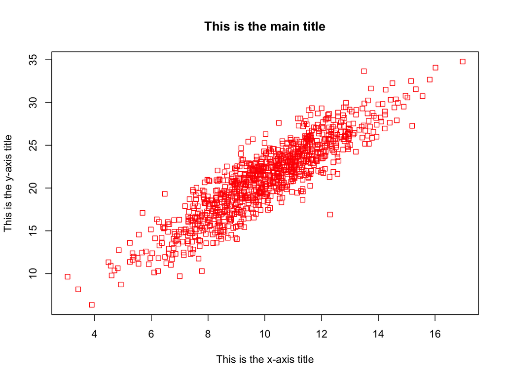

```r
plot(x, y, main = "This is the main title",
     xlab = "This is the x-axis title",
     ylab = "This is the y-axis title",
     col = "red",
     pch = 0)
```

# Save the plot as separate file

1. right click the plot–>copy and paste it to other programs (e.g., Microsoft Word) –> save as a new file
2. Use the `png()` function and the `dev.off()` function:

*Example: I want to save the scatter plot as a separate png file called scatter.png*

```r
#Three separate lines of code (they have to be in this order!)

#It asks R to create a new png file called scatter.png in the working directory
#with the dimension of 1200X800. All the graphs produced after this line of code
#will be put into the scatter.png file.
#(you can think of this as a “start recording button”)
png('scatter.png', width = 1200, height = 800)

#The second line is just the usual scatter plot function
plot(x,y)

#The third line is the dev.off() function.
#You don’t need to put anything within the parentheses.
#Any graphs produced between the first line (png() function)
#and this line will be put into the scatter.png file (“stop recording button”)
dev.off()
```

# Sampling

*Why sample?*:

We cannot ask every single person in our population (let’s say we are interested in income distribution of all USA residents (~350 million people))

Then, we need to *find a feasible way to do it*

We are going to draw a sample, that will resemble the whole population.

Why? Due to the properties of the *Central Limit Theorem*!

One condition: *sample must be random* to ensure that our sample *represents* the population (=resembles)

# Population vs. Sample vs. Sampling distribution

*Population*: The whole group of people you want to know

*Sample*: Part of the group of people you want to know

*Sampling*: The process to select/pick a sample

# Population vs. Sample vs. Sampling distribution

| Properties | Population | Sample | Sampling |
| --- | --- | --- | --- |
| Mean | 12.01 | 12.23 | 12.04 |
| Standard Deviation | 5.3 | 5.52 | 0.17 |

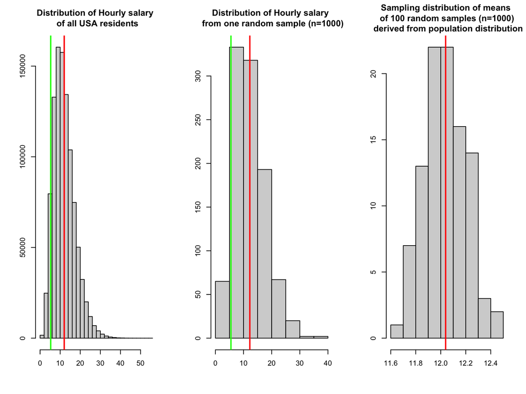

# Sampling

As you can see, if the sample is random, it’s mean is close to the population mean

How close?

• According to law of large numbers, if you have large sample size, the sample mean should be close to the population mean

• The larger the sample size, the closer the sample mean with the population mean

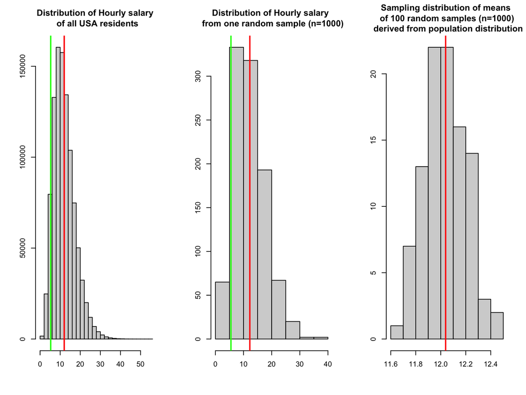

# Central Limit Theorem

*Note: n should be large enough (30+)*

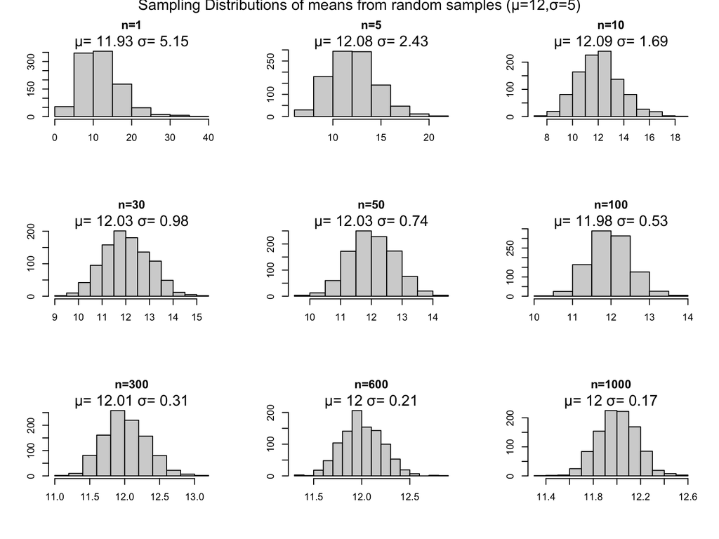

# Central Limit Theorem

No matter how skewed or weird the original distribution is, the sampling distribution would still be approximately normal:

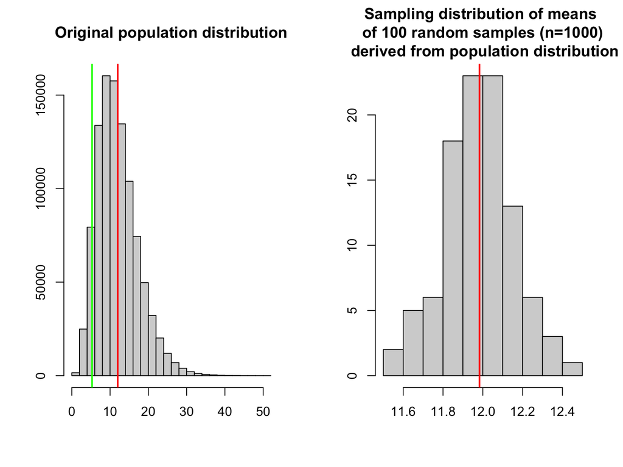

# Sampling Distribution

In reality:

*What we don’t know:*

- population mean

*What we know:*

- The sampling distribution is approximately normal
- The standard error (standard deviation of the sampling distribution) can be estimated using the standard deviation of the sample:

$StandardError = \frac{Sample SD}{\sqrt{n}}$

# HW3 Guide

- when you load the HW3.RData into RStudio, you will see the function `auto.sampler` in your Environment pane:

```r
load('HW3.RData')
```

[figure not shown]

### Q5 Guide

if you pass the only number within parentheses, it will give you one sample:

```r
x = auto.sampler(10000)
```

```
## Generating a sample of size 10000
```

Using this sample, write code in your HW 3.R script that will create:

1. Histogram of this sample (`hist()` function)
2. Mean of this sample (`mean()` function)
3. Standard deviation of this sample (`sd()` function)
4. Standard deviation of the sampling distribution (*Hint: you will need `sqrt()` function*)

### Q6, Q7, Q8 Guide

if you to get sample means for your four samples you need to write:

```r
means = auto.sampler(n=sample size, samples = number of samples)
```

replace `sample size` and `number of samples` with the ones that HW asks you to do.